# Charity Project - Part 3 (The Mailing List Problem)

Before proceeding I ensure that the processes I have implemented previously in part 1 to predict DAMT and part 2 to predict DONR are sourced from external files. This way any data processing steps that may need to be adjusted going forward are kept separate from the modeling step. These updates are provided in the file “steven_futter_data_preparation.R”. The optimal models for predicting DAMT and DONR are kept in another separate file called “steven_futter_save_my_models.R”. The model used to produce DAMT is a multiple linear regression model since this had the lowest MSE and the model used to predict DONR is a multiple logistic regression model.

```r
# Load packages required for this code.
library(glmnet)
```

##### Exercise 1

##### Read Data from CSV File

```r
# input source data file
inPath = file.path("~/Dropbox","NU","MACHINE_LEARNING","charity_project","part3")
valData = read.csv(file.path(inPath,"projectDataPart3.csv"),na.strings=c("NA"," "))

# Convert categorical variables to factors
valData$DONR = as.factor(valData$DONR)
valData$HOME = as.factor(valData$HOME)
valData$HINC = as.factor(valData$HINC)
```

#### Exercise 2

#### Predictions on Validation Set

Part A - Apply the Part 1 data processing steps to valData.

```r
codePath = file.path("~/Dropbox","NU","MACHINE_LEARNING","charity_project","part3")
source(file.path(codePath,"steven_futter_data_preparation.R"))

valDataPart1 = processPart1(valData)

## sanity check that data is found post data processing step from part 1
head(valDataPart1,10)
```

```
##     ID DAMT AGE HOME GENDER MEDAGE MEDPPH MEDHVAL MEDINC MEDEDUC NUMPROM
## 1   55    0  57    0   <NA>     45    177     494    321     120      21
## 2   59    0  32    1      F     39    258     747    458     120      15
## 3   88    0  90    1      F     43    194     645    317     120      48
## 4   94    0  40    1      M     28    304     575    220     140      38
## 5  102    0  49    1      M     36    230     710    333     120      60
## 6  109    0  50    1      M     39    159    1166    410     160      58
## 7  121    0  62    1      F     39    270    1706    609     140      76
## 8  135   20  78    1      M     37    215     392    258     123      67
## 9  139    0  73    1      M     56    149     688    273     140      74
## 10 183    0  56    1      F     48    168     544    337     120      13
##    NUMPRM12 RAMNTALL NGIFTALL MAXRAMNT LASTGIFT TDON LOG_MAXRAMNT
## 1        10       32        2       17       17   18     2.833213
## 2        12       23        1       23       23   16     3.135494
## 3        12      118        5       40       40   21     3.688879
```

[output cut: 18 more lines]

Part B - Predict DAMT for valData using the optimal multiple linear regression model from Part 1

```r
modelPath = file.path("~/Dropbox","NU","MACHINE_LEARNING","charity_project","part3")
load(file.path(modelPath,"modelPart1.RData"))

# Note that the model I am using is an lm model. Therefore, I must call the predict function
# using the syntax for an lm model. See class(modelPart1) on the command line to ensure that we have
# an lm model. Create new model matrix using validation data.
x = model.matrix(DAMT~.,data=valDataPart1)[,-1]
class(modelPart1) # lm model - good
```

```
## [1] "lm"
```

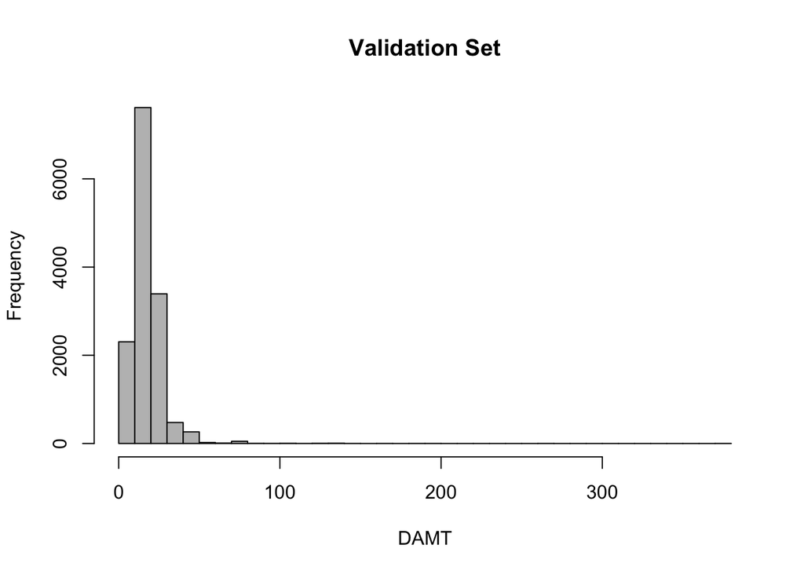

```r
# Predict DAMT values
# just want to make sure at this point that NO values less than ZERO enter the model:
valData$DAMT.Pred = ifelse(predict(modelPart1,newdata=valDataPart1)<0,
                           0,predict(modelPart1,newdata=valDataPart1))

# Check the predictions as a sanity check
hist(valData$DAMT.Pred,xlab="DAMT",main="Validation Set",col="gray",breaks=50)
```

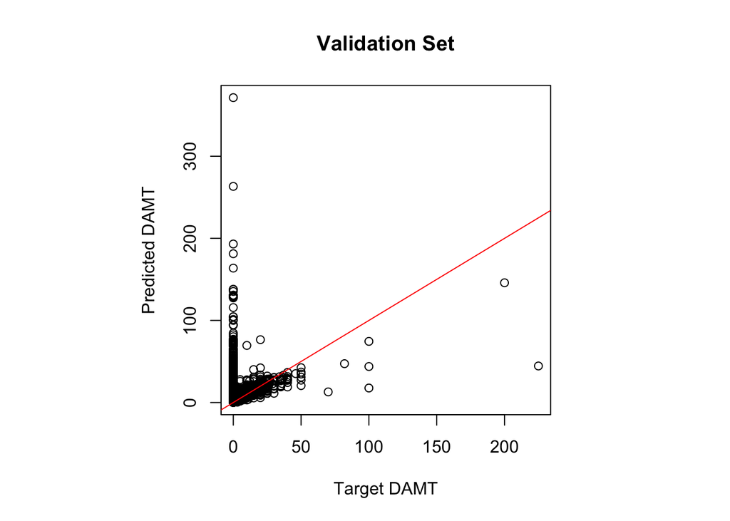

```r
par(pty="s")
plot(valData$DAMT,valData$DAMT.Pred,xlab="Target DAMT",ylab="Predicted DAMT",
     main="Validation Set")
abline(0,1,col="red")
```

```r
par(pty="m")
```

Part C - Apply the Part 2 data processing steps to valData

```r
valDataPart2 = processPart2(valData)
```

Part D - Predict DONR and PDONR for valData using your chosen model from Part 2 Recall that DONR = 0 or 1 is the predicted class and PDONR in [0,1] is the predicted probability.

```r
load(file.path(modelPath,"modelPart2.RData"))

# Note that the model I am using is a glm model. Therefore, I call the predict function
# using the syntax for the glm model. Search for help on predict.glm for details.
# Check that we have sourced the glm model.
class(modelPart2) #glm - good.
```

```
## [1] "glm" "lm"
```

```r
# Note that the modelPart2_prob_threshold was created using a ROC curve. See part 2 for details.
valData$PDONR.Pred = predict(modelPart2,newdata=valDataPart2,type="response")
valData$DONR.Pred  = ifelse(valData$PDONR.Pred > modelPart2_prob_threshold, 1, 0)

# Check the predictions as a sanity check
table(valData$DONR,valData$DONR.Pred,dnn=c("Target","Predicted"))
```

```
##       Predicted
## Target    0    1
##      0 8324 5440
##      1  348  427
```

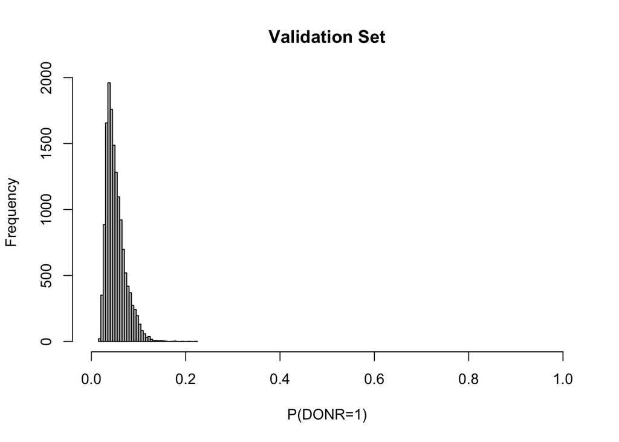

```r
hist(valData$PDONR.Pred,xlab="P(DONR=1)",main="Validation Set",col="gray",breaks=50,
     xlim=c(0,1))
```

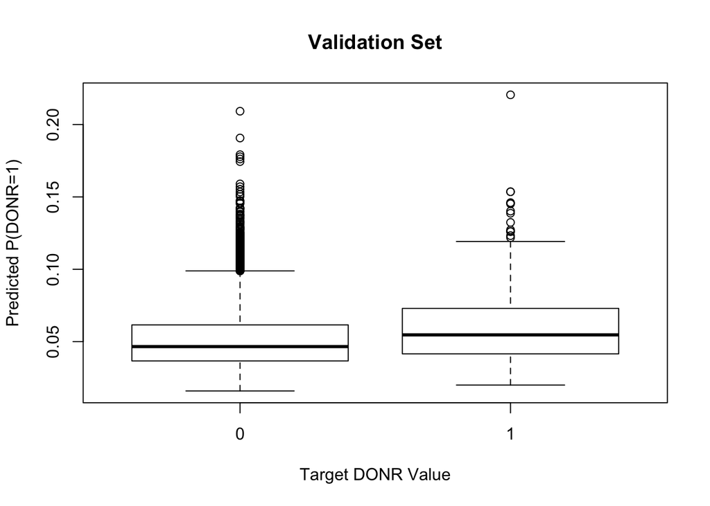

```r
plot(valData$DONR,valData$PDONR.Pred,xlab="Target DONR Value",
     ylab="Predicted P(DONR=1)",main="Validation Set")
```

#### Exercise 3

#### Mailing List Selection

First let’s “Source” the file RankedDonorOutput.R in order to put the function outputForRankedDonors into memory.

```r
source(file.path(codePath,"RankedDonorOutput.R"))

## Evaluate various mailing list strategies using function outputForRankedDonors

# Rank donors by PDONR.Pred
numBins = 10
out1 = outputForRankedDonors(numBins,rankVar="PDONR.Pred",dataToRank=valData)
print(out1$Donor.Table)
```

```
##    Num.Mailed Donors Donations Cum.Mailed Cum.Donors Cum.Donations
## 1        1454    146    1178.5       1454        146        1178.5
## 2        1454    103    1178.0       2908        249        2356.5
## 3        1454     80    1077.0       4362        329        3433.5
## 4        1454     92    1261.0       5816        421        4694.5
## 5        1453     88    1550.0       7269        509        6244.5
## 6        1454     60     954.0       8723        569        7198.5
## 7        1454     61    1162.0      10177        630        8360.5
## 8        1454     59    1375.0      11631        689        9735.5
## 9        1454     44    1189.0      13085        733       10924.5
## 10       1454     42    1108.0      14539        775       12032.5
```

```r
print(out1$Mailing.Table)
```

```
##    Bins.Mailed Num.Mailed Num.Donors Success.Rate Total.Cost
## 1     1 thru 1       1454        146    10.041265     988.72
## 2     1 thru 2       2908        249     8.562586    1977.44
## 3     1 thru 3       4362        329     7.542412    2966.16
## 4     1 thru 4       5816        421     7.238652    3954.88
## 5     1 thru 5       7269        509     7.002339    4942.92
## 6     1 thru 6       8723        569     6.522985    5931.64
## 7     1 thru 7      10177        630     6.190429    6920.36
## 8     1 thru 8      11631        689     5.923824    7909.08
## 9     1 thru 9      13085        733     5.601834    8897.80
## 10   1 thru 10      14539        775     5.330490    9886.52
##    Total.Donations Total.Profit Average.Donation
## 1           1178.5       189.78         8.071918
## 2           2356.5       379.06         9.463855
## 3           3433.5       467.34        10.436170
## 4           4694.5       739.62        11.150831
## 5           6244.5      1301.58        12.268173
## 6           7198.5      1266.86        12.651142
## 7           8360.5      1440.14        13.270635
## 8           9735.5      1826.42        14.129898
## 9          10924.5      2026.70        14.903820
## 10         12032.5      2145.98        15.525806
```

Total profit ranking donors by PDONR.Pred is maximized when all donors are targeted. This does not seem like an optimal solution. Let’s try using EXAMT.Pred instead so that we are also factoring in the predicted donation amount.

```r
# Rank donors by EXAMT.Pred (expected donation amount)
# EXAMT.Pred = PDONR.Pred * DAMT.Pred
# (likelihood of donation * predicted donation amount)
valData$EXAMT.Pred = valData$PDONR.Pred * valData$DAMT.Pred
# sum(is.na(valData$EXAMT.Pred))  #141 missing

# including this step below because there were 141 is.na values included in EXAMT.
valData$EXAMT.Pred = ifelse(is.na(valData$EXAMT.Pred),0,valData$EXAMT.Pred)

out2 = outputForRankedDonors(numBins,rankVar="EXAMT.Pred",dataToRank=valData)
print(out2$Donor.Table)
```

```
##    Num.Mailed Donors Donations Cum.Mailed Cum.Donors Cum.Donations
## 1        1454     82    2385.5       1454         82        2385.5
## 2        1454     71    1303.5       2908        153        3689.0
## 3        1454     66    1115.0       4362        219        4804.0
## 4        1454     65    1066.0       5816        284        5870.0
## 5        1453     80    1329.0       7269        364        7199.0
## 6        1454     62     941.0       8723        426        8140.0
## 7        1454     70    1046.5      10177        496        9186.5
## 8        1454     81     987.0      11631        577       10173.5
## 9        1454     87     903.0      13085        664       11076.5
## 10       1454    111     956.0      14539        775       12032.5
```

```r
print(out2$Mailing.Table)
```

```
##    Bins.Mailed Num.Mailed Num.Donors Success.Rate Total.Cost
## 1     1 thru 1       1454         82     5.639615     988.72
## 2     1 thru 2       2908        153     5.261348    1977.44
## 3     1 thru 3       4362        219     5.020633    2966.16
## 4     1 thru 4       5816        284     4.883081    3954.88
## 5     1 thru 5       7269        364     5.007566    4942.92
## 6     1 thru 6       8723        426     4.883641    5931.64
## 7     1 thru 7      10177        496     4.873735    6920.36
## 8     1 thru 8      11631        577     4.960880    7909.08
## 9     1 thru 9      13085        664     5.074513    8897.80
## 10   1 thru 10      14539        775     5.330490    9886.52
##    Total.Donations Total.Profit Average.Donation
## 1           2385.5      1396.78         29.09146
## 2           3689.0      1711.56         24.11111
## 3           4804.0      1837.84         21.93607
## 4           5870.0      1915.12         20.66901
## 5           7199.0      2256.08         19.77747
## 6           8140.0      2208.36         19.10798
## 7           9186.5      2266.14         18.52117
## 8          10173.5      2264.42         17.63172
## 9          11076.5      2178.70         16.68148
## 10         12032.5      2145.98         15.52581
```

Great news. The total profit using EXAMT.Pred as the ranking strategy has a higher optimal total profit by emailing the first 7 bins of potential donors. A profit of $2266.14 is expected. See the output from the ‘Profit Profiles’ plot below. We can see that profit is maximized when using EXAMT strategy at bin 7. By comparison profit is maximized when using the PDONR selection strategy by emailing ALL recipients.

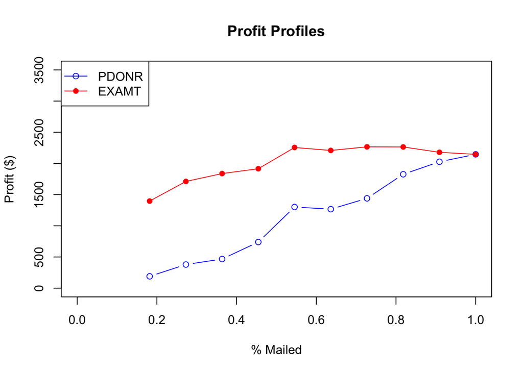

```r
# Plot profit profiles

# Calculate percentiles of breakVals for each profile using the empircal CDF function.
fn1 = ecdf(out1$breakVals)
fn2 = ecdf(out2$breakVals)
yLimits = c(0,500+1000*ceiling(max(c(out1$Mailing.Table$Total.Profit,out2$Mailing.Table$Total.Profit))/1000))
plot(fn1(out1$breakVals)[-1],out1$Mailing.Table$Total.Profit,type='b',col="blue",
     xlab="% Mailed",ylab="Profit ($)",main="Profit Profiles",xlim=c(0,1),ylim=yLimits)
lines(fn2(out2$breakVals)[-1],out2$Mailing.Table$Total.Profit,col="red")
points(fn2(out2$breakVals)[-1],out2$Mailing.Table$Total.Profit,col="red",pch=16)
legend(x="topleft",legend=c("PDONR","EXAMT"),col=c("blue","red"),lty=c(1,1),pch=c(1,16))
```

Let’s now select the top 7 bins determined by EXAMT.Pred and apply the cutoff to valData. We are left with 10177 observations.

```r
cutOff = out2$breakVals[numBins+1-7]
valMailList = data.frame(ID=valData$ID[valData$EXAMT.Pred >= cutOff])
length(valMailList$ID)
```

```
## [1] 10177
```

#### Exercise 4

#### Predictions on Test Set

Part A - Repeat Exercise 1 on projectDataTEST.csv

```r
testData = read.csv(file.path(inPath,"projectDataTEST.csv"),na.strings=c("NA"," "))
testData$HOME = as.factor(testData$HOME)
testData$HINC = as.factor(testData$HINC)
```

Part B - Repeat Exercise 2 on projectDataTEST.csv

```r
# Note: The model.matrix method will not allow us to use a dataframe with "missing"
# columns. Therefore, we add dummy DAMT and DONR columns to testData.
testData$DAMT = -1
testData$DONR = -1

## Apply the Part 1 data processing steps to testData
testDataPart1 = processPart1(testData)

## Predict DAMT for testData using your chosen model from Part 1
# Note that the model I am using is an lm model.
x = model.matrix(DAMT ~ .-ID,data=testDataPart1)[,-1]
testData$DAMT.Pred = predict(modelPart1,newdata=testDataPart1)

# Check the predictions as a sanity check
summary(testData$DAMT.Pred)  ### Update needed - predicts a min of -7.621 !! Needs to have min=0.
```

```
##     Min.  1st Qu.   Median     Mean  3rd Qu.     Max.     NA's
##   -7.621   11.540   16.880   17.830   20.430 5629.000     1557
```

```r
## Apply the Part 2 data processing steps to valData
testDataPart2 = processPart2(testData)

## Predict DONR and PDONR for valData using your chosen model from Part 2
testData$PDONR.Pred = predict(modelPart2,newdata=testDataPart2,type="response")
testData$DONR.Pred = ifelse(testData$PDONR.Pred > modelPart2_prob_threshold, 1, 0)

# Check the predictions as a sanity check
table(testData$DONR.Pred)
```

```
##
##     0     1
## 34429 23348
```

```r
summary(testData$PDONR.Pred)
```

```
##    Min. 1st Qu.  Median    Mean 3rd Qu.    Max.
## 0.01603 0.03697 0.04716 0.05203 0.06239 0.22050
```

Part C - Write Test Set Predictions to CSV File

```r
# Name the columns in the CSV file ID, DONR, PDONR, DAMT
testPredOut = data.frame(ID = testData$ID,
                         DONR = testData$DONR.Pred,
                         PDONR = testData$PDONR.Pred,
                         DAMT = testData$DAMT.Pred)

outPath = file.path("~/Dropbox/NU/MACHINE_LEARNING/charity_project/part3")

write.csv(testPredOut,file=file.path(outPath,"projectPredictionsTEST.csv"),row.names=FALSE)
```

Part D - Apply Mailing List Strategy to Test Data

```r
# Use bin 7 cutoff selected above.
testData$EXAMT.Pred = testData$PDONR.Pred * testData$DAMT.Pred
testMailList = data.frame(ID=testData$ID[testData$EXAMT.Pred >= cutOff])
length(valMailList$ID)
```

```
## [1] 10177
```

Part E - Write Test Set Mailing List to CSV File

```r
write.csv(testMailList,file=file.path(outPath,"projectListTEST.csv"),row.names=FALSE)
```